## Reshaping data

As we have seen, having data in `tidy` format is what makes the `tidyverse` flow. After the first step in the data analysis process, importing data, a common next step is to reshape the data into a form that facilitates the rest of the analysis. The `tidyr` package includes several functions that are useful for tidying data.

We will use the fertility wide format dataset described earlier as an example in this section.

```r
library(tidyverse)
library(dslabs)
filename <- "https://raw.githubusercontent.com/rafalab/dslabs/master/inst/extdata/fertility-two-countries-example.csv"
wide_data <- read_csv(filename)
head(wide_data)
```

```
## # A tibble: 2 × 57
##   country  `1960` `1961` `1962` `1963` `1964` `1965` `1966` `1967` `1968` `1969`
##   <chr>     <dbl>  <dbl>  <dbl>  <dbl>  <dbl>  <dbl>  <dbl>  <dbl>  <dbl>  <dbl>
## 1 Germany    2.41   2.44   2.47   2.49   2.49   2.48   2.44   2.37   2.28   2.17
## 2 South K…   6.16   5.99   5.79   5.57   5.36   5.16   4.99   4.85   4.73   4.62
## # ℹ 46 more variables: `1970` <dbl>, `1971` <dbl>, `1972` <dbl>, `1973` <dbl>,
## #   `1974` <dbl>, `1975` <dbl>, `1976` <dbl>, `1977` <dbl>, `1978` <dbl>,
## #   `1979` <dbl>, `1980` <dbl>, `1981` <dbl>, `1982` <dbl>, `1983` <dbl>,
## #   `1984` <dbl>, `1985` <dbl>, `1986` <dbl>, `1987` <dbl>, `1988` <dbl>,
## #   `1989` <dbl>, `1990` <dbl>, `1991` <dbl>, `1992` <dbl>, `1993` <dbl>,
## #   `1994` <dbl>, `1995` <dbl>, `1996` <dbl>, `1997` <dbl>, `1998` <dbl>,
## #   `1999` <dbl>, `2000` <dbl>, `2001` <dbl>, `2002` <dbl>, `2003` <dbl>, …
```

### `pivot_longer`

One of the most used functions in the tidyr package is `pivot_longer`, which is useful for converting wide data into tidy data.

As with most tidyverse functions, the `pivot_longer` function’s first argument is the data frame that will be converted. Here we want to reshape the `wide_data` dataset so that each row represents a fertility observation, which implies we need three columns to store the year, country, and the observed value. In its current form, data from different years are in different columns with the year values stored in the column names. Through the `names_to` and `values_to` argument we will tell `pivot_longer` the column names we want to assign to the columns containing the current column names and observations, respectively. The default names are `name` and `value`, which are often usable choices. In this case a better choice for these two arguments would be `year` and `fertility`. Note that nowhere in the data file does it tell us this is fertility data. Instead, we deciphered this from the file name. Through `cols`,the second argument we specify the columns containing observed values; these are the columns that will be pivoted. The default is to pivot all columns so, in most cases, we have to specify the columns. In our example we want columns `1960`, `1961` up to `2015`.

The code to pivot the fertility data therefore looks like this:

```r
new_tidy_data <- pivot_longer(wide_data, `1960`:`2015`, names_to = "year", values_to = "fertility")
```

We can also use the pipe like this:

```r
new_tidy_data <- wide_data %>%
  pivot_longer(`1960`:`2015`, names_to = "year", values_to = "fertility")
```

We can see that the data have been converted to tidy format with columns `year` and `fertility`:

```r
head(new_tidy_data)
```

```
## # A tibble: 6 × 3
##   country year  fertility
##   <chr>   <chr>     <dbl>
## 1 Germany 1960       2.41
## 2 Germany 1961       2.44
## 3 Germany 1962       2.47
## 4 Germany 1963       2.49
## 5 Germany 1964       2.49
## 6 Germany 1965       2.48
```

and that each year resulted in two rows since we have two countries and this column was not pivoted. A somewhat quicker way to write this code is to specify which column will not include in the pivot, rather than all the columns that will be pivoted:

```r
new_tidy_data <- wide_data %>%
  pivot_longer(-country, names_to = "year", values_to = "fertility")
```

The `new_tidy_data` object looks like the original `tidy_data` we defined this way

```r
data("gapminder")
tidy_data <- gapminder %>%
  filter(country %in% c("South Korea", "Germany") & !is.na(fertility)) %>%
  select(country, year, fertility)
```

with just one minor difference. Can you spot it? Look at the data type of the year column:

```r
class(tidy_data$year)
```

```
## [1] "integer"
```

```r
class(new_tidy_data$year)
```

```
## [1] "character"
```

The `pivot_longer` function assumes that column names are characters. So we need a bit more wrangling before we are ready to make a plot. We need to convert the year column to be numbers:

```r
new_tidy_data <- wide_data %>%
  pivot_longer(-country, names_to = "year", values_to = "fertility") %>%
  mutate(year = as.integer(year))
```

Note that we could have also used the `mutate` and `as.numeric`.

Now that the data is tidy, we can use this relatively simple ggplot code:

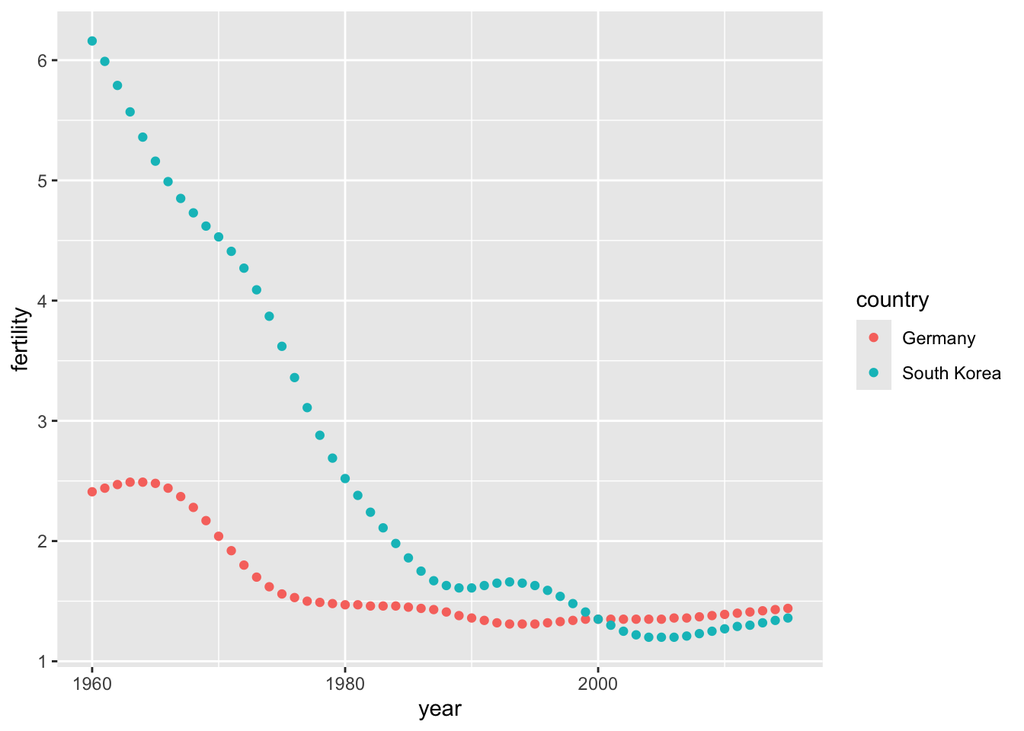

```r
new_tidy_data %>% ggplot(aes(year, fertility, color = country)) +
  geom_point()
```

### `pivot_wider`

As we will see in later examples, it is sometimes useful for data wrangling purposes to convert tidy data into wide data. We often use this as an intermediate step in tidying up data. The `pivot_wider` function is basically the inverse of `pivot_longer`. The first argument is for the data, but since we are using the pipe, we don’t show it. The `names_from` argument tells `pivot_wider` which variable will be used as the column names. The `values_from` argument specifies which variable to use to fill out the cells.

```r
new_wide_data <- new_tidy_data %>%
  pivot_wider(names_from = year, values_from = fertility)
select(new_wide_data, country, `1960`:`1967`)
```

```
## # A tibble: 2 × 9
##   country     `1960` `1961` `1962` `1963` `1964` `1965` `1966` `1967`
##   <chr>        <dbl>  <dbl>  <dbl>  <dbl>  <dbl>  <dbl>  <dbl>  <dbl>
## 1 Germany       2.41   2.44   2.47   2.49   2.49   2.48   2.44   2.37
## 2 South Korea   6.16   5.99   5.79   5.57   5.36   5.16   4.99   4.85
```

Similar to `pivot_longer`, `names_from` and `values_from` default to name and value.

### `separate`

The data wrangling shown above was simple compared to what is usually required. In our example spreadsheet files we include an example that is slightly more complicated. It includes two variables: life expectancy as well as fertility. However, the way it is stored is not tidy and, as we will explain, not optimal.

```r
path     <- system.file("extdata", package = "dslabs")
filename <- file.path(path, "life-expectancy-and-fertility-two-countries-example.csv")

raw_dat <- read_csv(filename)
select(raw_dat, 1:5)
```

```
## # A tibble: 2 × 5
##   country     `1960_fertility` `1960_life_expectancy` `1961_fertility`
##   <chr>                  <dbl>                  <dbl>            <dbl>
## 1 Germany                 2.41                   69.3             2.44
## 2 South Korea             6.16                   53.0             5.99
## # ℹ 1 more variable: `1961_life_expectancy` <dbl>
```

First, note that the data is in wide format. Second, notice that this table includes values for two variables, fertility and life expectancy, with the column name encoding which column represents which variable. Encoding information in the column names is not recommended but, unfortunately, it is quite common. We will put our wrangling skills to work to extract this information and store it in a tidy fashion.

We can start the data wrangling with the `pivot_longer function`, but we should no longer use the column name year for the new column since it also contains the variable type. We will call it `name`, the default, for now:

```r
dat <- raw_dat %>% pivot_longer(-country)
head(dat)
```

```
## # A tibble: 6 × 3
##   country name                 value
##   <chr>   <chr>                <dbl>
## 1 Germany 1960_fertility        2.41
## 2 Germany 1960_life_expectancy 69.3
## 3 Germany 1961_fertility        2.44
## 4 Germany 1961_life_expectancy 69.8
## 5 Germany 1962_fertility        2.47
## 6 Germany 1962_life_expectancy 70.0
```

The result is not exactly what we refer to as tidy since each observation is associated with two, not one, rows. We want to have the values from the two variables, fertility and life expectancy, in two separate columns. The first challenge to achieve this is to separate the `name` column into the year and the variable type. Notice that the entries in this column separate the year from the variable name with an underscore:

```r
dat$name[1:5]
```

```
## [1] "1960_fertility"       "1960_life_expectancy" "1961_fertility"
## [4] "1961_life_expectancy" "1962_fertility"
```

```r
dat %>% separate(name, c("year", "variable_name"), "_")
```

Because `_` is the default separator assumed by `separate`, we do not have to include it in the code:

```r
dat %>% separate(name, c("year", "variable_name"))
```

```
## Warning: Expected 2 pieces. Additional pieces discarded in 112 rows [2, 4, 6, 8, 10, 12,
## 14, 16, 18, 20, 22, 24, 26, 28, 30, 32, 34, 36, 38, 40, ...].
```

```
## # A tibble: 224 × 4
##    country year  variable_name value
##    <chr>   <chr> <chr>         <dbl>
##  1 Germany 1960  fertility      2.41
##  2 Germany 1960  life          69.3
##  3 Germany 1961  fertility      2.44
##  4 Germany 1961  life          69.8
##  5 Germany 1962  fertility      2.47
##  6 Germany 1962  life          70.0
##  7 Germany 1963  fertility      2.49
##  8 Germany 1963  life          70.1
##  9 Germany 1964  fertility      2.49
## 10 Germany 1964  life          70.7
## # ℹ 214 more rows
```

```r
var_names <- c("year", "first_variable_name", "second_variable_name")
dat %>% separate(name, var_names, fill = "right")
```

```
## # A tibble: 224 × 5
##    country year  first_variable_name second_variable_name value
##    <chr>   <chr> <chr>               <chr>                <dbl>
##  1 Germany 1960  fertility           <NA>                  2.41
##  2 Germany 1960  life                expectancy           69.3
##  3 Germany 1961  fertility           <NA>                  2.44
##  4 Germany 1961  life                expectancy           69.8
##  5 Germany 1962  fertility           <NA>                  2.47
##  6 Germany 1962  life                expectancy           70.0
##  7 Germany 1963  fertility           <NA>                  2.49
##  8 Germany 1963  life                expectancy           70.1
##  9 Germany 1964  fertility           <NA>                  2.49
## 10 Germany 1964  life                expectancy           70.7
## # ℹ 214 more rows
```

However, if we read the `separate` help file, we find that a better approach is to merge the last two variables when there is an extra separation:

```r
dat %>% separate(name, c("year", "name"), extra = "merge")
```

```
## # A tibble: 224 × 4
##    country year  name            value
##    <chr>   <chr> <chr>           <dbl>
##  1 Germany 1960  fertility        2.41
##  2 Germany 1960  life_expectancy 69.3
##  3 Germany 1961  fertility        2.44
##  4 Germany 1961  life_expectancy 69.8
##  5 Germany 1962  fertility        2.47
##  6 Germany 1962  life_expectancy 70.0
##  7 Germany 1963  fertility        2.49
##  8 Germany 1963  life_expectancy 70.1
##  9 Germany 1964  fertility        2.49
## 10 Germany 1964  life_expectancy 70.7
## # ℹ 214 more rows
```

This achieves the separation we wanted. However, we are not done yet. We need to create a column for each variable. As we learned, the `pivot_wider` function can do this:

```r
dat %>%
    separate(name, c("year", "name"), extra = "merge") %>%
            pivot_wider()
```

```
## # A tibble: 112 × 4
##    country year  fertility life_expectancy
##    <chr>   <chr>     <dbl>           <dbl>
##  1 Germany 1960       2.41            69.3
##  2 Germany 1961       2.44            69.8
##  3 Germany 1962       2.47            70.0
##  4 Germany 1963       2.49            70.1
##  5 Germany 1964       2.49            70.7
##  6 Germany 1965       2.48            70.6
##  7 Germany 1966       2.44            70.8
##  8 Germany 1967       2.37            71.0
##  9 Germany 1968       2.28            70.6
## 10 Germany 1969       2.17            70.5
## # ℹ 102 more rows
```

The data is now in tidy format with one row for each observation with three variables: `year`, `fertility` and `life expectancy`.

### `unite`

It is sometimes useful to do the inverse of `separate`, i.e. unite two columns into one. To demonstrate how to use unite, we show code that, although not the optimal approach, serves as an illustration. Suppose that we did not know about extra and used this command to separate:

```r
var_names <- c("year", "first_variable_name", "second_variable_name")
dat %>%
  separate(name, var_names, fill = "right")
```

```
## # A tibble: 224 × 5
##    country year  first_variable_name second_variable_name value
##    <chr>   <chr> <chr>               <chr>                <dbl>
##  1 Germany 1960  fertility           <NA>                  2.41
##  2 Germany 1960  life                expectancy           69.3
##  3 Germany 1961  fertility           <NA>                  2.44
##  4 Germany 1961  life                expectancy           69.8
##  5 Germany 1962  fertility           <NA>                  2.47
##  6 Germany 1962  life                expectancy           70.0
##  7 Germany 1963  fertility           <NA>                  2.49
##  8 Germany 1963  life                expectancy           70.1
##  9 Germany 1964  fertility           <NA>                  2.49
## 10 Germany 1964  life                expectancy           70.7
## # ℹ 214 more rows
```

we can achieve the same final result by uniting the second and third columns, then pivoting the columns and renaming `fertility_NA` to `fertility`:

```r
dat %>%
  separate(name, var_names, fill = "right") %>%
  unite(name, first_variable_name, second_variable_name) %>%
  pivot_wider() %>%
  rename(fertility = fertility_NA)
```

```
## # A tibble: 112 × 4
##    country year  fertility life_expectancy
##    <chr>   <chr>     <dbl>           <dbl>
##  1 Germany 1960       2.41            69.3
##  2 Germany 1961       2.44            69.8
##  3 Germany 1962       2.47            70.0
##  4 Germany 1963       2.49            70.1
##  5 Germany 1964       2.49            70.7
##  6 Germany 1965       2.48            70.6
##  7 Germany 1966       2.44            70.8
##  8 Germany 1967       2.37            71.0
##  9 Germany 1968       2.28            70.6
## 10 Germany 1969       2.17            70.5
## # ℹ 102 more rows
```